# Wrangle SPINS gradients with GSR

Grabbing SPINS gradients

```r
library(tidyverse)
library(ggseg)
library(ggsegGlasser)
library(broom)
```

## Read in the SPINS big table

```r
spins_grads_wGSR <- read_csv("../gsr_spins_concat_full")
```

```
## -------------------------------------------------------- Delimiter: "," chr
## (5): ROI, Task, Subject, Network, Site dbl (11): ...1, grad1, grad2, grad3,
## grad4, grad5, grad6, grad7, grad8, grad...
```

```r
# spins_grads <- spins_grads %>%
#   mutate(site = str_sub(`Subject`, 5, 7)) %>%
#   rename(task = `EA or RS`,
#          subject = `Subject ID`)
spins_grads_noGSR <- read_csv("../spins_concat_full")
```

```
## -------------------------------------------------------- Delimiter: "," chr
## (5): ROI, Task, Subject, Network, Site dbl (11): ...1, grad1, grad2, grad3,
## grad4, grad5, grad6, grad7, grad8, grad...
```

```r
spins_grads <- bind_rows("GSR" = spins_grads_wGSR,
                     "noGSR" = spins_grads_noGSR,
                     .id = "GSR")

rm(spins_grads_noGSR, spins_grads_wGSR)
```

## read subject data

```r
lol_spins_behav <-
  read_csv('../data/spins_lolivers_subject_info_for_grads_2022-04-20.csv') %>%
  filter(exclude_MRI==FALSE,
         exclude_meanFD==FALSE,
         exclude_earlyTerm==FALSE) %>%
  mutate(subject = str_c("sub-", str_sub(record_id, 7,9), str_sub(record_id, 11, -1))) %>%
  select(subject, scanner, diagnostic_group, demo_sex, demo_age_study_entry,
         scog_rmet_total, scog_er40_total, scog_mean_ea, scog_tasit1_total,
         scog_tasit2_parsar, scog_tasit2_simpsar, scog_tasit2_sinc,
         scog_tasit3_lie, scog_tasit3_sar, np_domain_tscore_att_vigilance,
         np_domain_tscore_process_speed, np_domain_tscore_work_mem,
         np_domain_tscore_verbal_learning, np_domain_tscore_visual_learning,
         np_domain_tscore_reasoning_ps,
         fd_mean_rest) %>%
    filter(complete.cases(.))
```

```
## -------------------------------------------------------- Delimiter: "," chr
## (4): record_id, scanner, diagnostic_group, demo_sex dbl (36): ...1,
## demo_age_study_entry, scog_rmet_total, scog_er40_total, scog... lgl (3):
## exclude_MRI, exclude_meanFD, exclude_earlyTerm
```

```r
names(lol_spins_behav)
```

```
##  [1] "subject"                          "scanner"
##  [3] "diagnostic_group"                 "demo_sex"
##  [5] "demo_age_study_entry"             "scog_rmet_total"
##  [7] "scog_er40_total"                  "scog_mean_ea"
##  [9] "scog_tasit1_total"                "scog_tasit2_parsar"
## [11] "scog_tasit2_simpsar"              "scog_tasit2_sinc"
## [13] "scog_tasit3_lie"                  "scog_tasit3_sar"
## [15] "np_domain_tscore_att_vigilance"   "np_domain_tscore_process_speed"
## [17] "np_domain_tscore_work_mem"        "np_domain_tscore_verbal_learning"
## [19] "np_domain_tscore_visual_learning" "np_domain_tscore_reasoning_ps"
## [21] "fd_mean_rest"
```

## grab some network colours

```r
networks <- read_delim("../networks.txt",
    "\t", escape_double = FALSE, trim_ws = TRUE) %>%
  select(NETWORK, NETWORKKEY, RED, GREEN, BLUE, ALPHA) %>%
  distinct() %>%
  add_row(NETWORK = "Subcortical", NETWORKKEY = 13, RED = 0, GREEN=0, BLUE=0, ALPHA=255) %>%
  mutate(hex = rgb(RED, GREEN, BLUE, maxColorValue = 255)) %>%
  arrange(NETWORKKEY)
networks
```

| NETWORK | NETWORKKEY | RED | GREEN | BLUE | ALPHA | hex |
| --- | --- | --- | --- | --- | --- | --- |
| Visual1 | 1 | 0 | 0 | 255 | 255 | #0000FF |
| Visual2 | 2 | 100 | 0 | 255 | 255 | #6400FF |
| Somatomotor | 3 | 0 | 255 | 255 | 255 | #00FFFF |
| Cingulo-Opercular | 4 | 153 | 0 | 153 | 255 | #990099 |
| Dorsal-Attention | 5 | 0 | 255 | 0 | 255 | #00FF00 |
| Language | 6 | 0 | 155 | 155 | 255 | #009B9B |
| Frontoparietal | 7 | 255 | 255 | 0 | 255 | #FFFF00 |
| Auditory | 8 | 250 | 62 | 251 | 255 | #FA3EFB |
| Default | 9 | 255 | 0 | 0 | 255 | #FF0000 |
| Posterior-Multimodal | 10 | 177 | 89 | 40 | 255 | #B15928 |

[output cut: 3 more lines]

## fitting models

Models

- model includes DX, sex, age, scanner, fd?
- what about between task -
  - do paired ttest?

So the current df is here: /projects/loliver/SPINS_PLS_Conn/data/processed/spins_behav_ea_conn_04-29-2021.csv 6:27 However, I also excluded ZHP_0110 and ZHP_0172 as they did not complete the soc cog tasks 6:27 So that df includes 356, but my current N is 354

The following participants were missing task-rest cleaned files: sub-CMP0180 sub-CMP0182 sub-CMP0191 sub-CMP0196 sub-CMP0198 sub-CMP0207 sub-CMP0213 sub-ZHH0034

The following participants were missing task-emp background files: sub-CMH0025 sub-CMH0044 sub-CMH0095 sub-CMH0138 sub-MRC0075 sub-MRP0077 sub-MRP0147 sub-MRP0149 sub-MRP0151 sub-MRP0161 sub-ZHH0038 sub-ZHP0061 sub-ZHP0086

```r
overall_grand_mean_grads <- spins_grads %>%
  mutate(Network = factor(Network, levels = networks$NETWORK)) %>%
  filter(Subject %in% lol_spins_behav$subject) %>%
  group_by(Task, ROI, Network, GSR) %>%
  summarise_at(vars(grad1:grad3), mean)

#grand_mean_grads
```

```r
## a very convoluted way to pull networks of interest
networks_of_interest <- overall_grand_mean_grads %>%
  group_by(Network) %>%
  summarise_at(vars(grad1:grad3), mean) %>%
  pivot_longer(starts_with("grad"),
               names_to = "grad_name",
               values_to = "grad_value") %>%
  filter(abs(grad_value) > 0.2) %>%
  distinct(Network) %>%
  pull(Network) %>% as.character()
```

```r
grand_mean_grads <- spins_grads %>%
  mutate(Network = factor(Network, levels = networks$NETWORK)) %>%
  filter(Subject %in% lol_spins_behav$subject) %>%
  group_by(Site, Task, ROI, Network, GSR) %>%
  summarise_at(vars(grad1:grad3), mean)

#grand_mean_grads
```

```r
glasser_atlas <-
  ggsegGlasser::glasser %>% as.tibble() %>% select(hemi, region, side, label)
```

```
## merging atlas and data by 'label'
```

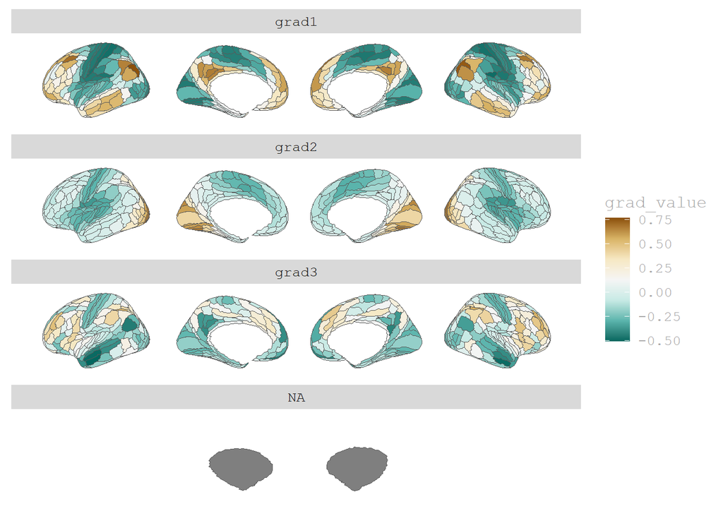

```r
overall_grads_for_plot <- overall_grand_mean_grads %>%
  mutate(roi = str_remove(ROI, "_ROI"),
         label = case_when(str_starts(ROI, "L") ~ str_c("lh_", roi),
                           str_starts(ROI, "R_") ~ str_c("rh_", roi))) %>%

  filter(Task == "RS", GSR == "GSR") %>%
  select(starts_with("grad"), label)
overall_grads_for_plot %>%
  pivot_longer(grad1:grad3,
               names_to = "grad_num",
               values_to = "grad_value") %>%
  filter(Network != "Subcortical") %>%
  filter(ROI != "L_10pp_ROI") %>%
  as.data.frame() %>%
  ggplot() +
  geom_brain(mapping = aes(fill = grad_value),
        atlas = glasser) +
  scale_fill_distiller(type = "div") +
  facet_wrap(~grad_num, ncol = 1) +
  theme_brain2()
```

```
## merging atlas and data by 'label'
```

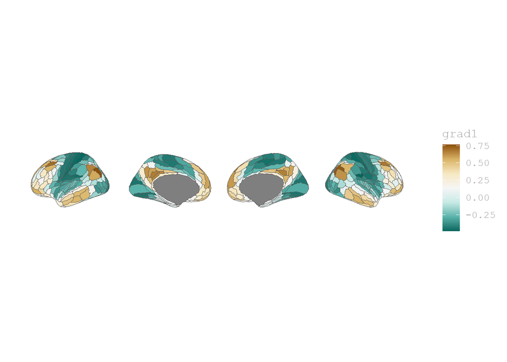

```r
overall_grads_for_plot %>%
  filter(Network != "Subcortical") %>%
  filter(ROI != "L_10pp_ROI") %>%
  as.data.frame() %>%
  ggplot() +
  geom_brain(mapping = aes(fill = grad1),
        atlas = glasser) +
  scale_fill_distiller(type = "div") +
  theme_brain2()
```

```
## merging atlas and data by 'label'
```

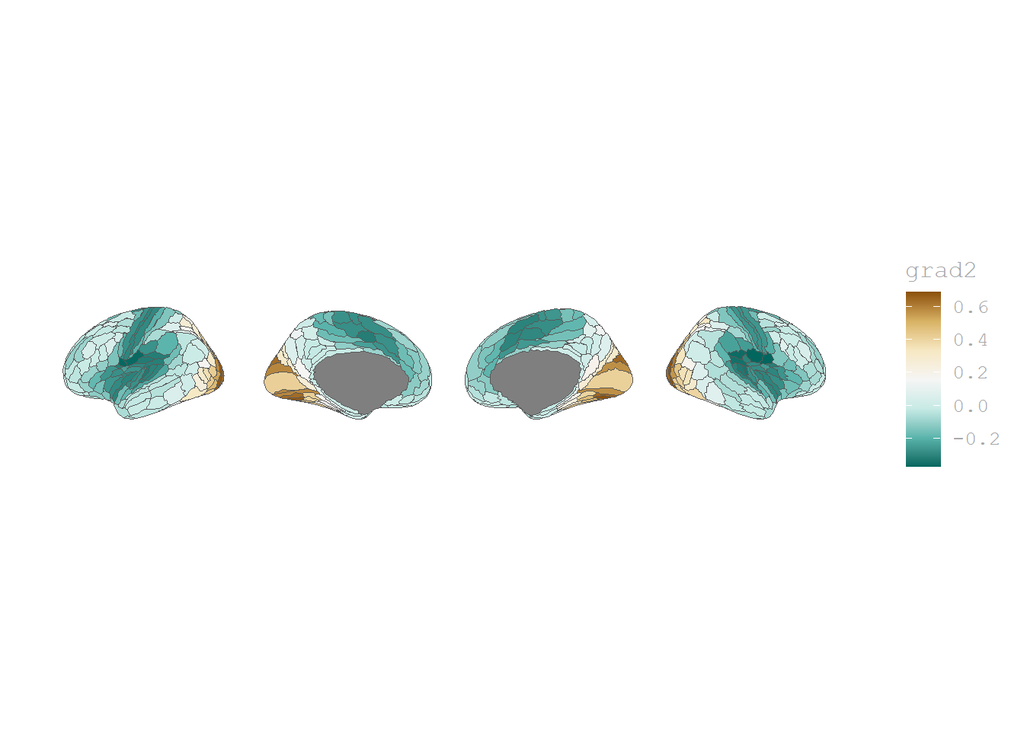

```r
overall_grads_for_plot %>%
  filter(Network != "Subcortical") %>%
  filter(ROI != "L_10pp_ROI") %>%
  as.data.frame() %>%
  ggplot() +
  geom_brain(mapping = aes(fill = grad2),
        atlas = glasser) +
  scale_fill_distiller(type = "div") +
  theme_brain2()
```

```
## merging atlas and data by 'label'
```

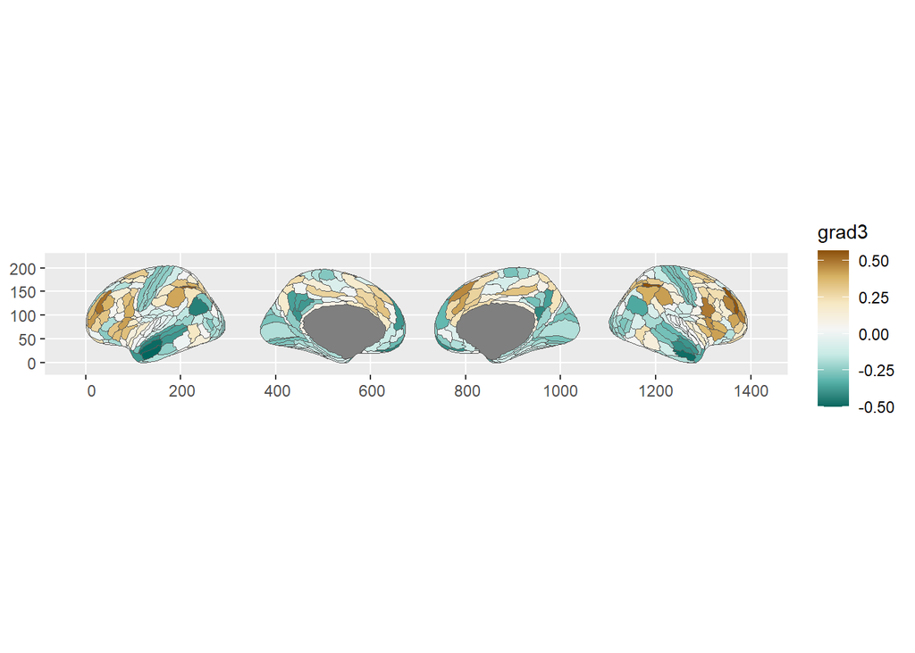

```r
overall_grads_for_plot %>%
  filter(Network != "Subcortical") %>%
  filter(ROI != "L_10pp_ROI") %>%
  as.data.frame() %>%
  ggplot() +
  geom_brain(mapping = aes(fill = grad3),
        atlas = glasser) +
  scale_fill_distiller(type = "div")
```

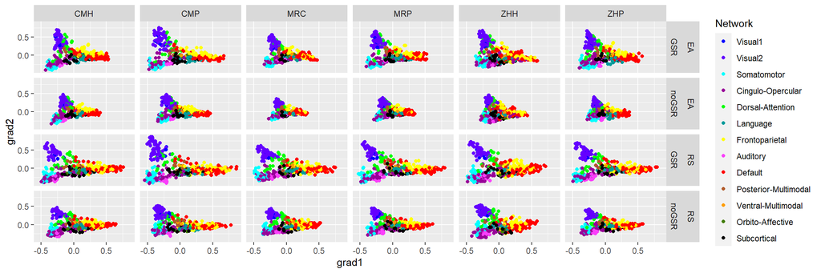

```r
grand_mean_grads %>%
  ggplot(aes(x = grad1, y = grad2, colour = Network)) +
  geom_point() +
  scale_color_manual(values = networks$hex) +
  facet_grid(Task*GSR ~ Site)
```

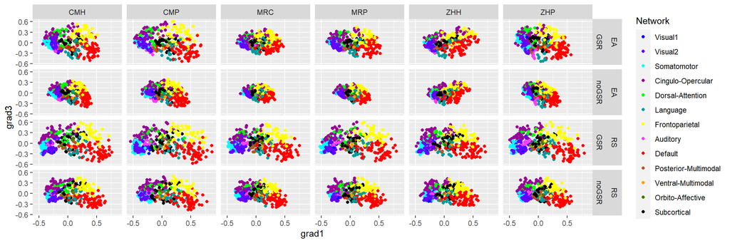

```r
grand_mean_grads %>%
  ggplot(aes(x = grad1, y = grad3, colour = Network)) +
  geom_point() +
  scale_color_manual(values = networks$hex) +
  facet_grid(Task*GSR ~ Site)
```

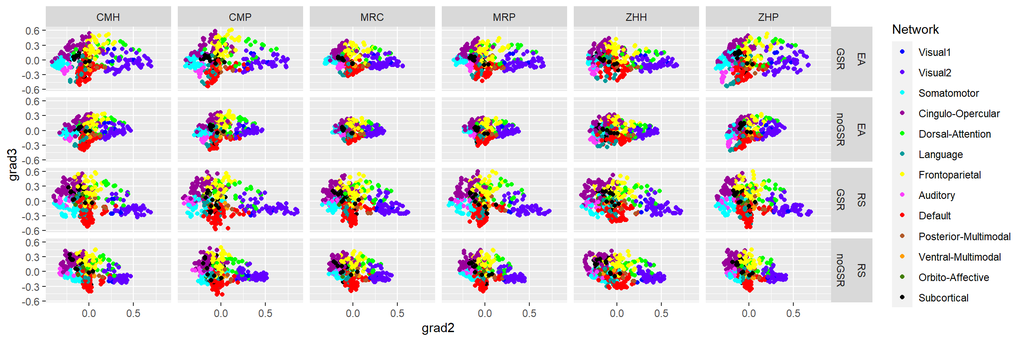

```r
grand_mean_grads %>%
  ggplot(aes(x = grad2, y = grad3, colour = Network)) +
  geom_point() +
  scale_color_manual(values = networks$hex) +
  facet_grid(Task*GSR ~ Site)
```

From age paper: Each axis of this 3D space was defined by the values along the first three gradients. Within network dispersion was quantified as sum squared Euclidean distance of network nodes to the network centroid at individual level. Between network dispersion was calculated as the Euclidean distance between network centroids.

They also did linear models on nodal values from the first three gradients

## calculating centroid and within network dispersion

```r
## calculate the network centers
subject_level_centers <- spins_grads %>%
  filter(Subject %in% lol_spins_behav$subject) %>%
  group_by(Site, Task, Network, Subject, GSR) %>%
  summarise_at(c("grad1", "grad2", "grad3"), mean)

subject_within_dispersion <- subject_level_centers %>%

  ## combine with orig spins grads
  inner_join(spins_grads, by = c("Site", "Task", "Network", "Subject", "GSR"), suffix = c("_center", "")) %>%

  ## calculate squared euclidian distance from the network centroid
  ungroup() %>%
  mutate(roi_distance_sq = (grad1_center - grad1)**2 + (grad2_center - grad2)**2 + (grad3_center - grad3)**2) %>%

  ## dispersion as the sum of the squared distances within network and participant
  group_by(Site, Task, GSR, Network, Subject) %>%
  summarise(within_dispersion = sum(roi_distance_sq))
```

## calculating between network dispersion

Between network dispersion was calculated as the Euclidean distance between network centroids.

```r
library(igraph)
## assumes that the network_centroids contains columns "Network", "grad1", "grad2", "grad3"
calc_between_distances <- function(network_centoids) {
  ## grab the unique network node names
  network_names <- unique(network_centoids$Network)

  ## create a graph dataframe of edges
  result <- make_full_graph(length(network_names), directed = FALSE) %>% as_data_frame()

  for (i in 1:nrow(result)) {
    to_name <- network_names[result$to[i]]
    from_name <- network_names[result$from[i]]

    result$to_name[i] <- to_name
    result$from_name[i] <- from_name

  res_df <- test_centroids %>%
    filter(Network == to_name | Network == from_name) %>%
    mutate_at(vars(c("grad1", "grad2", "grad3")), function(x) {(x - lag(x))**2}) %>%
    mutate(eucl_dist = sqrt(grad1 + grad2 + grad3))

  result$eucl_dist[i] <- res_df$eucl_dist[2]

  }

  return(result %>% select(to_name, from_name, eucl_dist))
}
```

```r
between_network <- subject_level_centers %>%
  ungroup() %>%
  group_by(Site, Task, Subject, GSR) %>%
  nest() %>%
  mutate(distances = map(data, calc_between_distances))
```

```r
between_network <- subject_level_centers %>%
  ungroup() %>%
  group_by(Site, Task, Subject, GSR) %>%
  nest() %>%
  slice(1)

between_network$data
```

## testing for EMP vs REST differences

```r
# dropping this b/c task emp fd mean not in current sheet
subject_level_centers %>%
  filter(GSR=="GSR") %>%
  inner_join(lol_spins_behav, by = c("Subject" = "subject")) %>%
  mutate( fd_mean = if_else(Task=="EA", `fd_mean_task-emp`, `fd_mean_task-rest`)) %>%
  ungroup() %>%
  group_by(Network, GSR) %>%
  do(tidy(aov(grad1 ~ Task + fd_mean + scanner + Error(Subject), data = .))) %>%
  filter(term == "Task") %>%
  arrange(GSR) %>%
  knitr::kable()
```

```r
library(table1)
# diagnostic_group + demo_age_study_entry + demo_sex + fd_mean + scanner
lol_spins_behav %>%
  drop_na(fd_mean_rest) %>%
  mutate(site = str_sub(scanner, 1,2)) %>%
  semi_join(subject_within_dispersion, by = c("subject" = "Subject")) %>%
  select(diagnostic_group, demo_age_study_entry, demo_sex, `fd_mean_rest`, site) %>%
  distinct() %>%
  table1(~ demo_age_study_entry + demo_sex + site + `fd_mean_rest` | diagnostic_group, data = .)
```

|  | case (N=220) | control (N=166) | Overall (N=386) |
| --- | --- | --- | --- |
| demo_age_study_entry |  |  |  |
| Mean (SD) | 32.0 (9.79) | 32.2 (10.5) | 32.1 (10.1) |
| Median [Min, Max] | 30.0 [18.0, 55.0] | 29.0 [18.0, 55.0] | 30.0 [18.0, 55.0] |
| demo_sex |  |  |  |
| female | 68 (30.9%) | 77 (46.4%) | 145 (37.6%) |
| male | 152 (69.1%) | 89 (53.6%) | 241 (62.4%) |
| site |  |  |  |
| CM | 90 (40.9%) | 54 (32.5%) | 144 (37.3%) |
| MR | 75 (34.1%) | 57 (34.3%) | 132 (34.2%) |
| ZH | 55 (25.0%) | 55 (33.1%) | 110 (28.5%) |
| fd_mean_rest |  |  |  |
| Mean (SD) | 0.157 (0.0975) | 0.142 (0.0743) | 0.150 (0.0885) |
| Median [Min, Max] | 0.124 [0.0406, 0.498] | 0.122 [0.0457, 0.458] | 0.123 [0.0406, 0.498] |

## fit case-control and age differences in gradient dispersion

```r
results_subject_within_dispersion <- subject_within_dispersion %>%
  filter(GSR=="GSR", Task=="RS") %>%
  inner_join(lol_spins_behav, by = c("Subject" = "subject")) %>%
  group_by(Network, Task, GSR) %>%
  do(tidy(lm(within_dispersion ~ diagnostic_group + demo_age_study_entry + demo_sex + fd_mean_rest + scanner, data = .))) %>%
  ungroup() %>%
  group_by(term) %>%
  mutate(p_FDR = p.adjust(p.value, method = "fdr"))

results_subject_within_dispersion %>%
  filter(term %in% c("diagnostic_groupcontrol",
                     "demo_age_study_entry")) %>%
  arrange(GSR) %>%
  filter(Network %in% networks_of_interest) %>%
  knitr::kable()
```

| Network | Task | GSR | term | estimate | std.error | statistic | p.value | p_FDR |
| --- | --- | --- | --- | --- | --- | --- | --- | --- |
| Auditory | RS | GSR | diagnostic_groupcontrol | 0.0738239 | 0.0640864 | 1.1519438 | 0.2500761 | 0.3612210 |
| Auditory | RS | GSR | demo_age_study_entry | -0.0009031 | 0.0034279 | -0.2634677 | 0.7923345 | 0.9464614 |
| Default | RS | GSR | diagnostic_groupcontrol | 0.1930962 | 0.4573966 | 0.4221637 | 0.6731468 | 0.7493051 |
| Default | RS | GSR | demo_age_study_entry | -0.0016440 | 0.0244655 | -0.0671959 | 0.9464614 | 0.9464614 |
| Frontoparietal | RS | GSR | diagnostic_groupcontrol | -0.7988896 | 0.3002705 | -2.6605661 | 0.0081350 | 0.0710134 |
| Frontoparietal | RS | GSR | demo_age_study_entry | -0.0193529 | 0.0160610 | -1.2049575 | 0.2289775 | 0.9230973 |
| Somatomotor | RS | GSR | diagnostic_groupcontrol | 0.5092736 | 0.2112292 | 2.4110001 | 0.0163877 | 0.0710134 |
| Somatomotor | RS | GSR | demo_age_study_entry | -0.0019502 | 0.0112983 | -0.1726063 | 0.8630537 | 0.9464614 |
| Visual1 | RS | GSR | diagnostic_groupcontrol | -0.0781530 | 0.0535247 | -1.4601275 | 0.1450900 | 0.2889283 |
| Visual1 | RS | GSR | demo_age_study_entry | -0.0010099 | 0.0028630 | -0.3527489 | 0.7244744 | 0.9464614 |
| Visual2 | RS | GSR | diagnostic_groupcontrol | 0.1322032 | 0.3731153 | 0.3543225 | 0.7232958 | 0.7493051 |
| Visual2 | RS | GSR | demo_age_study_entry | -0.0139975 | 0.0199574 | -0.7013689 | 0.4835067 | 0.9464614 |

```r
results_subject_within_dispersion %>%
  filter(term == "demo_age_study_entry") %>%
  knitr::kable()
```

| Network | Task | GSR | term | estimate | std.error | statistic | p.value | p_FDR |
| --- | --- | --- | --- | --- | --- | --- | --- | --- |
| Auditory | RS | GSR | demo_age_study_entry | -0.0009031 | 0.0034279 | -0.2634677 | 0.7923345 | 0.9464614 |
| Cingulo-Opercular | RS | GSR | demo_age_study_entry | -0.0159840 | 0.0165728 | -0.9644731 | 0.3354287 | 0.9230973 |
| Default | RS | GSR | demo_age_study_entry | -0.0016440 | 0.0244655 | -0.0671959 | 0.9464614 | 0.9464614 |
| Dorsal-Attention | RS | GSR | demo_age_study_entry | 0.0082328 | 0.0088907 | 0.9260048 | 0.3550374 | 0.9230973 |
| Frontoparietal | RS | GSR | demo_age_study_entry | -0.0193529 | 0.0160610 | -1.2049575 | 0.2289775 | 0.9230973 |
| Language | RS | GSR | demo_age_study_entry | -0.0018979 | 0.0086176 | -0.2202307 | 0.8258110 | 0.9464614 |
| Orbito-Affective | RS | GSR | demo_age_study_entry | 0.0034195 | 0.0017504 | 1.9535985 | 0.0514899 | 0.6693688 |
| Posterior-Multimodal | RS | GSR | demo_age_study_entry | 0.0003488 | 0.0035785 | 0.0974752 | 0.9224009 | 0.9464614 |
| Somatomotor | RS | GSR | demo_age_study_entry | -0.0019502 | 0.0112983 | -0.1726063 | 0.8630537 | 0.9464614 |
| Subcortical | RS | GSR | demo_age_study_entry | -0.0122038 | 0.0098460 | -1.2394767 | 0.2159421 | 0.9230973 |
| Ventral-Multimodal | RS | GSR | demo_age_study_entry | 0.0002137 | 0.0011912 | 0.1793599 | 0.8577517 | 0.9464614 |
| Visual1 | RS | GSR | demo_age_study_entry | -0.0010099 | 0.0028630 | -0.3527489 | 0.7244744 | 0.9464614 |
| Visual2 | RS | GSR | demo_age_study_entry | -0.0139975 | 0.0199574 | -0.7013689 | 0.4835067 | 0.9464614 |

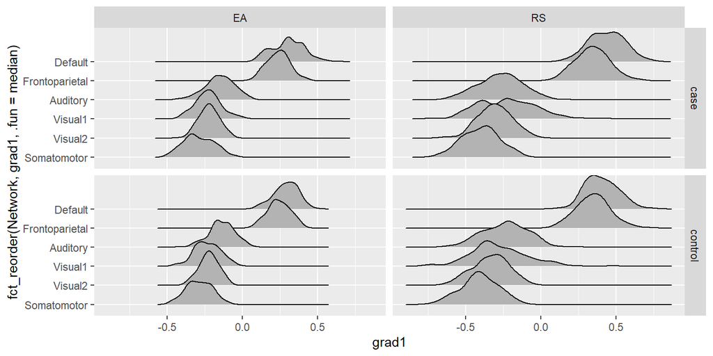

```r
library(ggridges)
library(forcats)
subject_level_centers %>%
  filter(GSR=="GSR") %>%
  filter(Network %in% networks_of_interest) %>%
  inner_join(lol_spins_behav, by = c("Subject" = "subject")) %>%
  ggplot(aes(x = grad1, y = fct_reorder(Network, grad1, .fun = median))) +
  geom_density_ridges() +
  # scale_fill_manual(values = networks$hex) +
  facet_grid(diagnostic_group~Task)
```

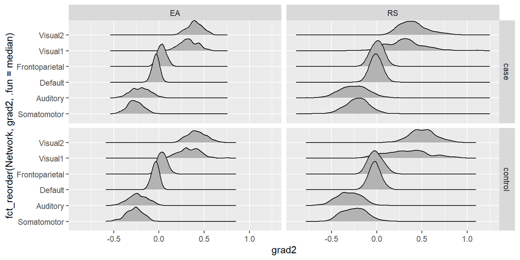

```r
subject_level_centers %>%
  filter(GSR=="GSR") %>%
  filter(Network %in% networks_of_interest) %>%
  inner_join(lol_spins_behav, by = c("Subject" = "subject")) %>%
  ggplot(aes(x = grad2, y = fct_reorder(Network, grad2, .fun = median))) +
  geom_density_ridges() +
  # scale_fill_manual(values = networks$hex) +
  facet_grid(diagnostic_group~Task)
```

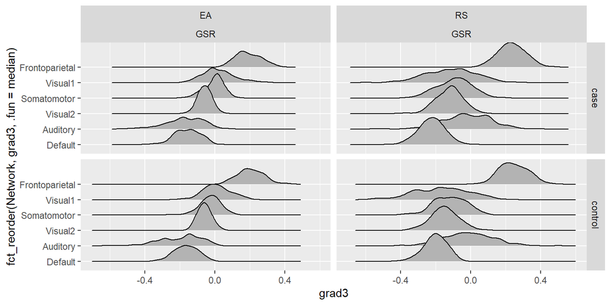

```r
subject_level_centers %>%
  filter(GSR=="GSR") %>%
  filter(Network %in% networks_of_interest) %>%
  inner_join(lol_spins_behav, by = c("Subject" = "subject")) %>%
  ggplot(aes(x = grad3, y = fct_reorder(Network, grad3, .fun = median))) +
  geom_density_ridges() +
  # scale_fill_manual(values = networks$hex) +
  facet_grid(diagnostic_group~Task*GSR)
```

## fit network locations against case-control

```r
net_centroids_results <- subject_level_centers %>%
  filter(GSR=="GSR", Task == "RS") %>%
  inner_join(lol_spins_behav, by = c("Subject" = "subject")) %>%
  pivot_longer(starts_with("grad"), names_to = "grad_num", values_to = "grad_value") %>%
    ungroup() %>%
  group_by(Network, Task, GSR, grad_num) %>%
  do(tidy(lm(grad_value ~ diagnostic_group + demo_age_study_entry + demo_sex + fd_mean_rest + scanner, data = .))) %>%
  ungroup() %>%
  group_by(term) %>%
  mutate(p_FDR = p.adjust(p.value, method = "fdr"))

net_centroids_results %>%
  filter(term == "diagnostic_groupcontrol") %>%
  filter(Network %in% networks_of_interest, GSR == "GSR") %>%
  knitr::kable()
```

| Network | Task | GSR | grad_num | term | estimate | std.error | statistic | p.value | p_FDR |
| --- | --- | --- | --- | --- | --- | --- | --- | --- | --- |
| Auditory | RS | GSR | grad1 | diagnostic_groupcontrol | 0.0334276 | 0.0153000 | 2.1848025 | 0.0295202 | 0.0719554 |
| Auditory | RS | GSR | grad2 | diagnostic_groupcontrol | -0.0628833 | 0.0154094 | -4.0808372 | 0.0000548 | 0.0004277 |
| Auditory | RS | GSR | grad3 | diagnostic_groupcontrol | 0.0105828 | 0.0147524 | 0.7173591 | 0.4735980 | 0.5724012 |
| Default | RS | GSR | grad1 | diagnostic_groupcontrol | -0.0417515 | 0.0116110 | -3.5958524 | 0.0003664 | 0.0014291 |
| Default | RS | GSR | grad2 | diagnostic_groupcontrol | -0.0102744 | 0.0063659 | -1.6139652 | 0.1073738 | 0.1903445 |
| Default | RS | GSR | grad3 | diagnostic_groupcontrol | 0.0246514 | 0.0068218 | 3.6136072 | 0.0003430 | 0.0014291 |
| Frontoparietal | RS | GSR | grad1 | diagnostic_groupcontrol | 0.0012421 | 0.0115288 | 0.1077404 | 0.9142591 | 0.9499287 |
| Frontoparietal | RS | GSR | grad2 | diagnostic_groupcontrol | -0.0146235 | 0.0073035 | -2.0022593 | 0.0459746 | 0.0996116 |
| Frontoparietal | RS | GSR | grad3 | diagnostic_groupcontrol | 0.0082973 | 0.0080519 | 1.0304742 | 0.3034498 | 0.4226623 |
| Somatomotor | RS | GSR | grad1 | diagnostic_groupcontrol | -0.0037428 | 0.0128173 | -0.2920116 | 0.7704388 | 0.8357879 |
| Somatomotor | RS | GSR | grad2 | diagnostic_groupcontrol | -0.0348291 | 0.0135268 | -2.5748260 | 0.0104107 | 0.0290012 |
| Somatomotor | RS | GSR | grad3 | diagnostic_groupcontrol | -0.0263169 | 0.0099953 | -2.6329296 | 0.0088143 | 0.0264429 |
| Visual1 | RS | GSR | grad1 | diagnostic_groupcontrol | -0.0617760 | 0.0206742 | -2.9880745 | 0.0029917 | 0.0097230 |
| Visual1 | RS | GSR | grad2 | diagnostic_groupcontrol | 0.0184998 | 0.0242731 | 0.7621521 | 0.4464471 | 0.5616592 |
| Visual1 | RS | GSR | grad3 | diagnostic_groupcontrol | -0.0573511 | 0.0157221 | -3.6477964 | 0.0003018 | 0.0014291 |
| Visual2 | RS | GSR | grad1 | diagnostic_groupcontrol | -0.0246840 | 0.0121384 | -2.0335531 | 0.0426984 | 0.0979552 |
| Visual2 | RS | GSR | grad2 | diagnostic_groupcontrol | 0.1137109 | 0.0151696 | 7.4959853 | 0.0000000 | 0.0000000 |
| Visual2 | RS | GSR | grad3 | diagnostic_groupcontrol | -0.0290019 | 0.0079689 | -3.6394074 | 0.0003115 | 0.0014291 |

```r
all_roi_results <- spins_grads %>%
  filter(GSR=="GSR", Task == "RS") %>%
  inner_join(lol_spins_behav, by = c("Subject" = "subject")) %>%
  pivot_longer(grad1:grad3, names_to = "grad_num", values_to = "grad_value") %>%
    ungroup() %>%
  group_by(Network, Task, , GSR, grad_num, ROI) %>%
  do(tidy(lm(grad_value ~ diagnostic_group + demo_age_study_entry + demo_sex + fd_mean_rest + scanner, data = .))) %>%
  ungroup() %>%
  group_by(term) %>%
  mutate(p_FDR = p.adjust(p.value, method = "fdr"))

#all_roi_results %>% write_csv('ROIwise_SPINS_SSDvsHC_result_wGSR.csv')
```

```r
all_roi_results %>%
  filter(term == "diagnostic_groupcontrol",
         Task == "RS",
         p_FDR < 0.5)
```

| Network | Task | GSR | grad_num | ROI | term | estimate | std.error | statistic | p.value | p_FDR |
| --- | --- | --- | --- | --- | --- | --- | --- | --- | --- | --- |
| Auditory | RS | GSR | grad1 | L_52_ROI | diagnostic_groupcontrol | 0.03082598 | 0.02501623 | 1.232239 | 2.186298e-01 | 4.518605e-01 |
| Auditory | RS | GSR | grad1 | L_A4_ROI | diagnostic_groupcontrol | 0.04394534 | 0.02496310 | 1.760412 | 7.915092e-02 | 2.405206e-01 |
| Auditory | RS | GSR | grad1 | L_LBelt_ROI | diagnostic_groupcontrol | 0.02834687 | 0.02432243 | 1.165462 | 2.445708e-01 | 4.783519e-01 |
| Auditory | RS | GSR | grad1 | L_PBelt_ROI | diagnostic_groupcontrol | 0.03847264 | 0.02329375 | 1.651629 | 9.944507e-02 | 2.771265e-01 |
| Auditory | RS | GSR | grad1 | L_TA2_ROI | diagnostic_groupcontrol | 0.03301266 | 0.02439594 | 1.353203 | 1.768039e-01 | 3.952878e-01 |
| Auditory | RS | GSR | grad1 | R_A1_ROI | diagnostic_groupcontrol | 0.05716766 | 0.02354690 | 2.427821 | 1.565843e-02 | 8.118029e-02 |
| Auditory | RS | GSR | grad1 | R_MBelt_ROI | diagnostic_groupcontrol | 0.05897194 | 0.02492130 | 2.366327 | 1.847181e-02 | 9.047249e-02 |
| Auditory | RS | GSR | grad1 | R_PBelt_ROI | diagnostic_groupcontrol | 0.05355052 | 0.02325892 | 2.302365 | 2.186021e-02 | 1.001189e-01 |
| Auditory | RS | GSR | grad1 | R_TA2_ROI | diagnostic_groupcontrol | 0.03284853 | 0.02343706 | 1.401563 | 1.618705e-01 | 3.725240e-01 |
| Auditory | RS | GSR | grad2 | L_52_ROI | diagnostic_groupcontrol | -0.07720236 | 0.02496822 | -3.092025 | 2.136304e-03 | 2.129063e-02 |

[output cut: 606 more lines]

```
## merging atlas and data by 'label'
```

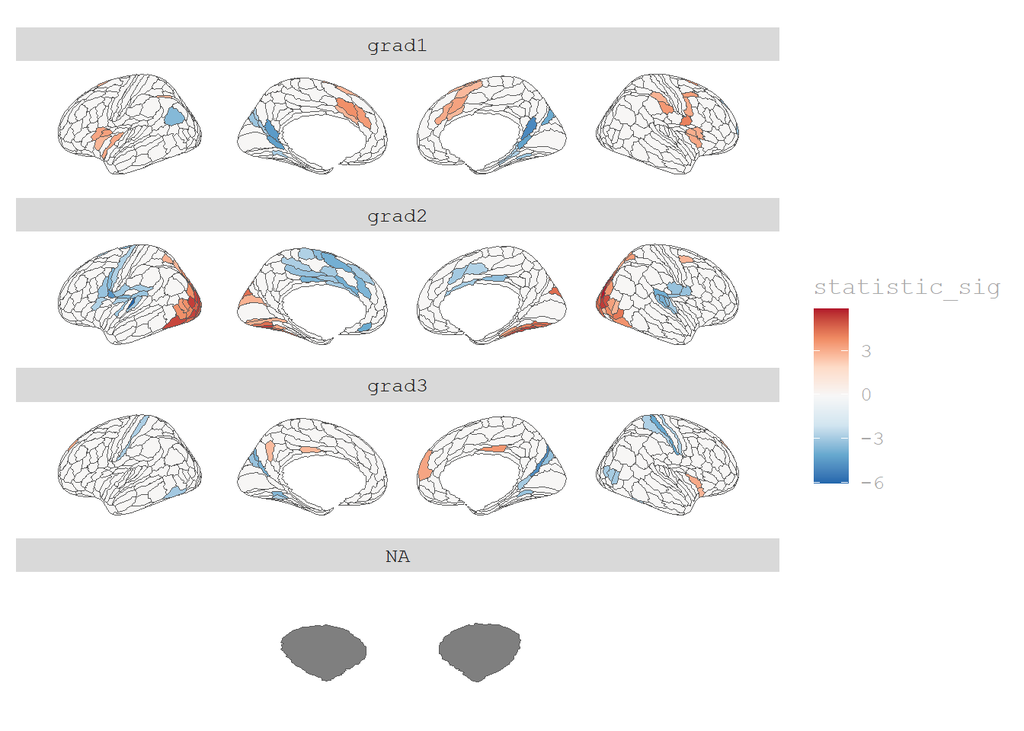

```r
all_roi_results %>%

  filter(term == "diagnostic_groupcontrol",
         Task == "RS") %>%
  mutate(statistic_sig = if_else(p_FDR < 0.05, statistic, 0),
         roi = str_remove(ROI, "_ROI"),
         label = case_when(str_starts(ROI, "L") ~ str_c("lh_", roi),
                           str_starts(ROI, "R_") ~ str_c("rh_", roi))) %>%
  filter(Network != "Subcortical") %>%
  filter(ROI != "L_10pp_ROI") %>%
  as.data.frame() %>%
  ggplot() +
  geom_brain(mapping = aes(fill = statistic_sig),
        atlas = glasser) +
  scale_fill_distiller(palette = "RdBu") +
  facet_wrap(~grad_num, ncol = 1) +
  theme_brain2()
```

```r
all_roi_results %>%
  filter(term == "diagnostic_groupcontrol", p_FDR < 0.05)
```

| Network | Task | GSR | grad_num | ROI | term | estimate | std.error | statistic | p.value | p_FDR |
| --- | --- | --- | --- | --- | --- | --- | --- | --- | --- | --- |
| Auditory | RS | GSR | grad2 | L_52_ROI | diagnostic_groupcontrol | -0.07720236 | 0.02496822 | -3.092025 | 2.136304e-03 | 2.129063e-02 |
| Auditory | RS | GSR | grad2 | L_A1_ROI | diagnostic_groupcontrol | -0.13216536 | 0.02182201 | -6.056517 | 3.375076e-09 | 3.969090e-06 |
| Auditory | RS | GSR | grad2 | L_LBelt_ROI | diagnostic_groupcontrol | -0.06836032 | 0.02261912 | -3.022236 | 2.681009e-03 | 2.562773e-02 |
| Auditory | RS | GSR | grad2 | L_RI_ROI | diagnostic_groupcontrol | -0.07556995 | 0.02389632 | -3.162409 | 1.691816e-03 | 1.825299e-02 |
| Auditory | RS | GSR | grad2 | R_A1_ROI | diagnostic_groupcontrol | -0.07549827 | 0.02235414 | -3.377373 | 8.082664e-04 | 1.188152e-02 |
| Auditory | RS | GSR | grad2 | R_LBelt_ROI | diagnostic_groupcontrol | -0.08365811 | 0.02210161 | -3.785159 | 1.787187e-04 | 3.868483e-03 |
| Auditory | RS | GSR | grad2 | R_MBelt_ROI | diagnostic_groupcontrol | -0.06489841 | 0.02247572 | -2.887490 | 4.107738e-03 | 3.286190e-02 |
| Auditory | RS | GSR | grad2 | R_PBelt_ROI | diagnostic_groupcontrol | -0.07716800 | 0.02288360 | -3.372197 | 8.231522e-04 | 1.195095e-02 |
| Cingulo-Opercular | RS | GSR | grad1 | L_6ma_ROI | diagnostic_groupcontrol | 0.08478019 | 0.02886594 | 2.937032 | 3.517702e-03 | 2.976128e-02 |
| Cingulo-Opercular | RS | GSR | grad1 | L_a24pr_ROI | diagnostic_groupcontrol | 0.06294256 | 0.02236661 | 2.814131 | 5.148026e-03 | 3.699615e-02 |

[output cut: 172 more lines]

```r
all_roi_results %>%
  filter(term == "diagnostic_groupcontrol", p_FDR < 0.05) %>%
  count(Task,GSR, grad_num) %>%
  arrange(Task, GSR, grad_num)
```

| term | Task | GSR | grad_num | n |
| --- | --- | --- | --- | --- |
| diagnostic_groupcontrol | RS | GSR | grad1 | 48 |
| diagnostic_groupcontrol | RS | GSR | grad2 | 99 |
| diagnostic_groupcontrol | RS | GSR | grad3 | 35 |

```r
all_roi_results %>%
  filter(term == "diagnostic_groupcontrol", p_FDR < 0.05) %>%
  count(Task, GSR, grad_num, Network) %>%
  pivot_wider(names_from = grad_num, values_from = n)
```

| term | Task | GSR | Network | grad1 | grad2 | grad3 |
| --- | --- | --- | --- | --- | --- | --- |
| diagnostic_groupcontrol | RS | GSR | Cingulo-Opercular | 18 | 15 | 1 |
| diagnostic_groupcontrol | RS | GSR | Default | 7 | 4 | 6 |
| diagnostic_groupcontrol | RS | GSR | Dorsal-Attention | 1 | 7 | 1 |
| diagnostic_groupcontrol | RS | GSR | Frontoparietal | 2 | 2 | NA |
| diagnostic_groupcontrol | RS | GSR | Language | 3 | NA | NA |
| diagnostic_groupcontrol | RS | GSR | Somatomotor | 1 | 11 | 4 |
| diagnostic_groupcontrol | RS | GSR | Subcortical | 6 | 6 | 7 |
| diagnostic_groupcontrol | RS | GSR | Visual1 | 3 | NA | 3 |
| diagnostic_groupcontrol | RS | GSR | Visual2 | 7 | 46 | 12 |
| diagnostic_groupcontrol | RS | GSR | Auditory | NA | 8 | NA |

[output cut: 1 more lines]

# Mass net centres vs clinical vars

```r
symptom_vars <- c("bprs_factor_total", "bprs_factor_neg_symp",
                  "bprs_factor_neg_symp",
                   "sans_total_sc")

net_centroids_symptoms_results <- subject_level_centers %>%
  filter(GSR=="GSR", Task == "RS") %>%
  inner_join(lol_spins_behav, by = c("Subject" = "subject")) %>%
  mutate( fd_mean = if_else(Task=="EA", `fd_mean_task-emp`, `fd_mean_task-rest`)) %>%
  pivot_longer(starts_with("grad"), names_to = "grad_num", values_to = "grad_value") %>%
  pivot_longer(all_of(symptom_vars), names_to = "symptom_scale", values_to = "symp_value") %>%
    ungroup() %>%
  group_by(Network, Task, GSR, grad_num, symptom_scale) %>%
  do(tidy(lm(grad_value ~ symp_value + demo_age_study_entry + demo_sex + fd_mean + scanner, data = .))) %>%
  ungroup() %>%
  group_by(term) %>%
  mutate(p_FDR = p.adjust(p.value, method = "fdr"))

net_centroids_symptoms_results %>%
  filter(term == "symp_value") %>%
  filter(Network %in% networks_of_interest, GSR == "GSR") %>%
  arrange(symptom_scale, grad_num) %>%
  knitr::kable()
```

### plot sans total score agains auditory grad2

```r
subject_level_centers %>%
  filter(GSR=="GSR", Task == "RS") %>%
  inner_join(lol_spins_behav, by = c("Subject" = "subject")) %>%
  filter(Network == "Auditory") %>%
  ggplot(aes(x = diagnostic_group, y = grad2)) +
    geom_boxplot(outlier.shape = NULL) +
    geom_jitter(aes(colour = diagnostic_group)) +
  labs(y = "Auditory Network Gradient 2 value (negative is more defined from visual)")
```

```r
subject_level_centers %>%
  filter(GSR=="GSR", Task == "RS") %>%
  inner_join(lol_spins_behav, by = c("Subject" = "subject")) %>%
  filter(Network == "Auditory") %>%
  ggplot(aes(x = sans_total_sc, y = grad2)) +
    geom_point(aes(colour = diagnostic_group)) +
    geom_smooth(method = "lm")
```

```r
subject_level_centers %>%
  filter(GSR=="GSR", Task == "RS") %>%
  inner_join(lol_spins_behav, by = c("Subject" = "subject")) %>%
  filter(Network == "Auditory") %>%
  ggplot(aes(x = sans_total_sc, y = grad2)) +
    geom_point(aes(colour = diagnostic_group)) +
    geom_smooth(method = "lm") +
  facet_wrap(~site)
```

—> ROIwise SANS by grad2

## neurocog and functioning my grads

```r
functioning_vars <- c("qls_total", "bsfs_total")

net_centroids_functioning_results <- subject_level_centers %>%
  filter(GSR=="GSR", Task == "RS") %>%
  inner_join(lol_spins_behav, by = c("Subject" = "subject")) %>%
  mutate( fd_mean = if_else(Task=="EA", `fd_mean_task-emp`, `fd_mean_task-rest`)) %>%
  pivot_longer(starts_with("grad"), names_to = "grad_num", values_to = "grad_value") %>%
  pivot_longer(all_of(functioning_vars), names_to = "func_scale", values_to = "func_value") %>%
    ungroup() %>%
  group_by(Network, Task, GSR, grad_num, func_scale) %>%
  do(tidy(lm(grad_value ~ func_value + demo_age_study_entry + demo_sex + fd_mean + scanner, data = .))) %>%
  ungroup() %>%
  group_by(term) %>%
  mutate(p_FDR = p.adjust(p.value, method = "fdr"))

net_centroids_functioning_results %>%
  filter(term == "func_value") %>%
  filter(Network %in% networks_of_interest, GSR == "GSR") %>%
  arrange(func_scale, grad_num) %>%
  knitr::kable()
```

```r
subject_level_centers %>%
  filter(GSR=="GSR", Task == "RS") %>%
  inner_join(lol_spins_behav, by = c("Subject" = "subject")) %>%
  filter(Network == "Visual1") %>%
  ggplot(aes(x = bsfs_total, y = grad1, colour = diagnostic_group)) +
    geom_point() +
    geom_smooth(method = "lm")
```

```r
subject_level_centers %>%
  filter(GSR=="GSR", Task == "RS") %>%
  inner_join(lol_spins_behav, by = c("Subject" = "subject")) %>%
  filter(Network == "Auditory") %>%
  ggplot(aes(x = bsfs_total, y = grad2, colour = diagnostic_group)) +
    geom_point() +
    geom_smooth(method = "lm")
```

```r
subject_level_centers %>%
  filter(GSR=="GSR", Task == "RS") %>%
  inner_join(lol_spins_behav, by = c("Subject" = "subject")) %>%
  filter(Network == "Visual2") %>%
  ggplot(aes(x = qls_total, y = grad2, colour = diagnostic_group)) +
    geom_point() +
    geom_smooth(method = "lm")
```

## Just the two vars for the SOBP abstract

```r
functioning_vars <- c("sans_total_sc", "bsfs_total")

net_centroids_functioning_results <- subject_level_centers %>%
  filter(GSR=="GSR",
         Task == "RS") %>%
  inner_join(lol_spins_behav, by = c("Subject" = "subject")) %>%
  mutate( fd_mean = if_else(Task=="EA", `fd_mean_task-emp`, `fd_mean_task-rest`)) %>%
  pivot_longer(starts_with("grad"), names_to = "grad_num", values_to = "grad_value") %>%
  pivot_longer(all_of(functioning_vars), names_to = "func_scale", values_to = "func_value") %>%
    ungroup() %>%
  group_by(Network, Task, GSR, grad_num, func_scale) %>%
  do(tidy(lm(grad_value ~ func_value + demo_age_study_entry + demo_sex + fd_mean + scanner, data = .))) %>%
  ungroup() %>%
  group_by(term) %>%
  mutate(p_FDR = p.adjust(p.value, method = "fdr"))

net_centroids_functioning_results %>%
  filter(term == "func_value") %>%
  filter(Network %in% networks_of_interest, GSR == "GSR") %>%
  arrange(func_scale, grad_num) %>%
  knitr::kable()
```

## Gradient values against cognition

```r
net_centroids_functioning_results <- subject_level_centers %>%
  filter(GSR=="GSR", Task == "RS") %>%
  inner_join(lol_spins_behav, by = c("Subject" = "subject")) %>%
  mutate( fd_mean = if_else(Task=="EA", `fd_mean_task-emp`, `fd_mean_task-rest`)) %>%
  pivot_longer(starts_with("grad"), names_to = "grad_num", values_to = "grad_value") %>%
  pivot_longer(scog_tasit1_total:np_domain_tscore_social_cog, names_to = "cog_scale", values_to = "cog_value") %>%
    ungroup() %>%
  group_by(Network, Task, GSR, grad_num, cog_scale) %>%
  do(tidy(lm(grad_value ~ cog_value  + demo_age_study_entry + demo_sex + fd_mean + scanner, data = .))) %>%
  ungroup() %>%
  group_by(term) %>%
  mutate(p_FDR = p.adjust(p.value, method = "fdr"))

net_centroids_functioning_results %>%
  filter(term == "cog_value") %>%
  filter(Network %in% networks_of_interest, GSR == "GSR") %>%
  arrange(cog_scale, grad_num) %>%
  knitr::kable()
```

```r
subject_level_centers %>%
  filter(GSR=="GSR", Task == "RS") %>%
  inner_join(lol_spins_behav, by = c("Subject" = "subject")) %>%
  filter(Network == "Visual2") %>%
  ggplot(aes(x = np_composite_tscore, y = grad2, colour = diagnostic_group)) +
    geom_point() +
    geom_smooth(method = "lm")
```

```r
lol_spins_behav %>%
  ggplot(aes(x = sans_total_sc, y = `fd_mean_task-rest`)) +
  geom_point()
```